# Estimator explaination

Cherubael

## Описание исходных данных

Исходные данные имеют следующий вид:

| session | name | time | curr.time | duration | x.coord | y.coord | hand |
| --- | --- | --- | --- | --- | --- | --- | --- |
| 1535561252769 | Иванов, И.И. | 1.535561e+12 | 1 | 34 | 0.5348485 | 0.5129629 | right |
| 1535561252769 | Иванов, И.И. | 1.535561e+12 | 2 | 23 | 0.5343434 | 0.5064815 | right |
| 1535561252769 | Иванов, И.И. | 1.535561e+12 | 2 | 31 | 0.5393940 | 0.5064815 | right |
| 1535561252769 | Иванов, И.И. | 1.535561e+12 | 2 | 31 | 0.5484849 | 0.5009259 | right |
| 1535561252769 | Иванов, И.И. | 1.535561e+12 | 2 | 43 | 0.5520202 | 0.5000000 | right |
| 1535561252769 | Иванов, И.И. | 1.535561e+12 | 2 | 42 | 0.5535353 | 0.4990741 | right |

где:

- *session* - идетификатор сессии исследования, равный времени начала теста,
- *name* - идетификатор испытуемого,
- *time* - текущее время, в которое произошло прикосновение к экрану,
- *curr.time* - количество секунд, прошедших с начала теста,
- *duration* - продолжительность касания,
- *x.coord* и *y.coord* - координаты прикосновения на экране мобильного устройства, нормированные относительно размеров экрана,
- *hand* - идентификатор руки.

# Интервал между касаниями

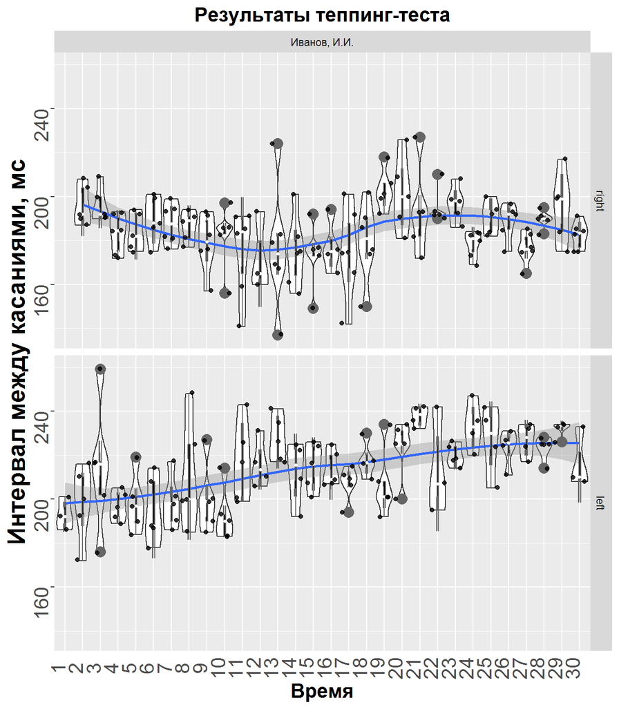

Данные о среднем значении±среднее квадратическое отклонение для интервалов между касаниями для правой и левой руки используются как один из показателей:

- *Правая рука* - 187.41±24.41 миллисекунд.
- *Левая рука* - 214.72±20.60 миллисекунд.

# Продолжительность касания

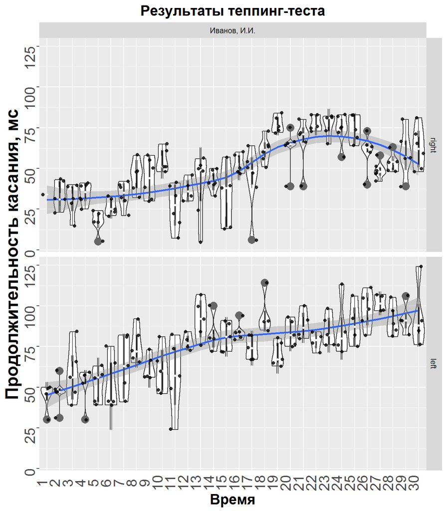

Средняя продолжительность касания для правой и левой руки также имеют аналитическую ценность:

- *Правая рука* - 49.63±19.62 миллисекунд.
- *Левая рука* - 74.83±19.88 миллисекунд.

# Скорость касания (отношение интервала между касаниями к их продолжительности)

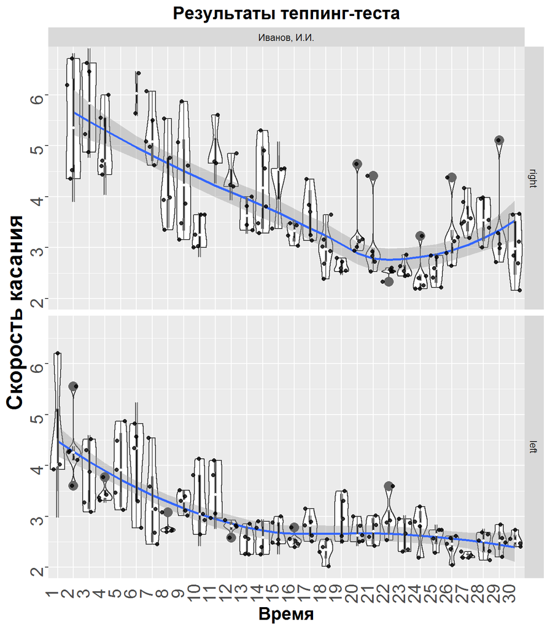

Скорость касания:

- *Правая рука* - 4.95±4.25.
- *Левая рука* - 3.07±0.91.

Кроме того, определенным интересом обладает корреляция между интервалом между касаниями и продолжительностью касания:

- *Правая рука* - 0.3442.
- *Левая рука* - 0.7780.

# Количество касаний в секунду

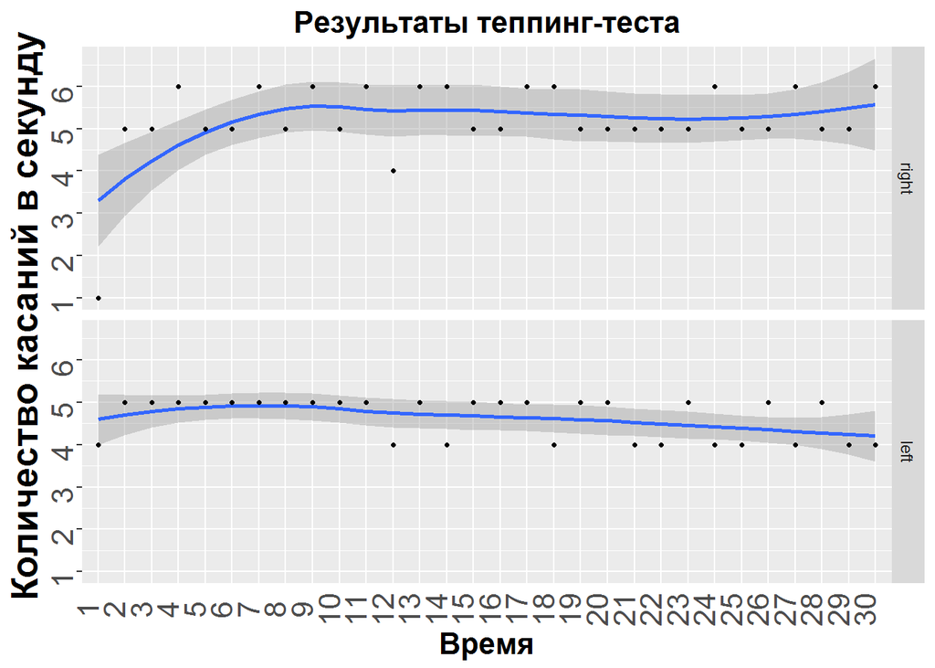

Данные о количестве касаний в секунду обрабатываются аналогичным образом и сохраняются для дальнейшей обработки:

- *Правая рука* - 5.20±0.96 касаний в секунду.
- *Левая рука* - 4.63±0.49 касаний в секунду.

# Кумулятивная сумма касаний в секунду

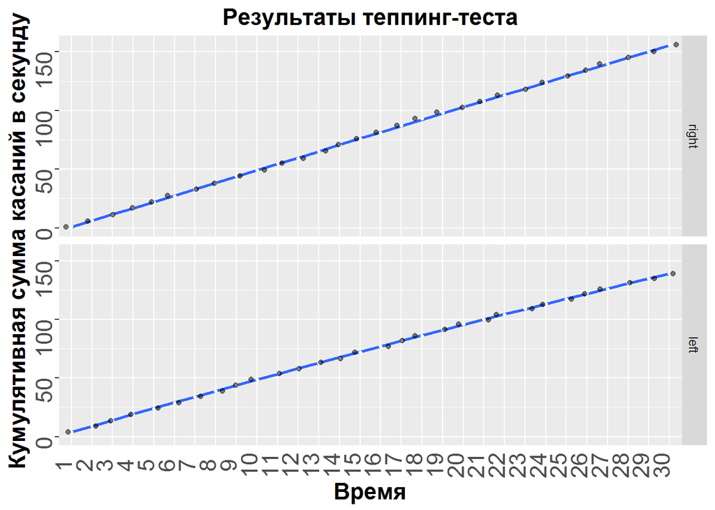

Такие показатели, как коэффициент наклона прямой и коэффициент детерминации ($R^2$) для правой и левой руки также вычисляются и сохраняются для дальнейшей обработки.

# Коэффициент силы нервной системы (КСНС)

КСНС вычисляется по формуле:

КСНС = ((х2 - х1) + (х3 - х1) + … + (х30 - х1)) : х1 * 100,

где x1, …, x30 - количество прикосновений в заданный промежуток времени.

Для текущего примера КСНС для правой руки равен: 1.26. Для левой: 0.05.

# Коэффициент функциональной асимметрии по работоспособности левой и правой рук

Коэффициент функциональной асимметрии по работоспособности левой и правой рук рассчитывается как:

KFa = ((ΣR - ΣL) : (ΣR + ΣL)) * 100,

где ΣR - сумма касаний правой рукой, ΣL - сумма касаний левой рукой.

Для текущего примера коэффициент функциональной асимметрии по работоспособности левой и правой рук для правой руки равен: 5.76.

# Плотность касаний в процессе прохождения теппинг-теста

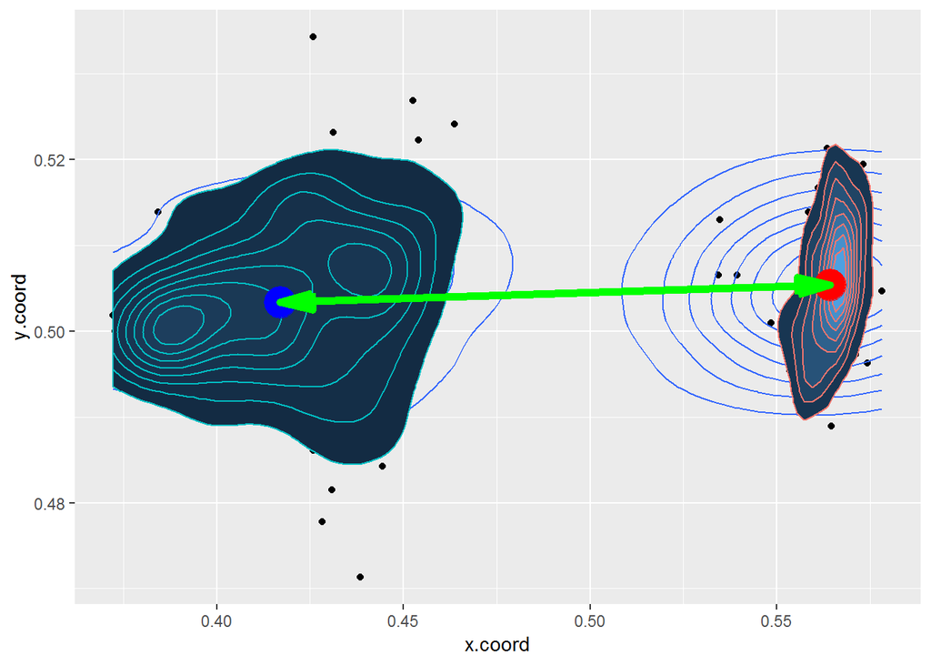

# Результаты

Итоговый объект, содержащий результаты имеет следующий вид:

| Показатель | Численное значение |
| --- | --- |
| name | Иванов, И.И. |
| interval.mean.right | 187.4065 |
| interval.mean.left | 214.7174 |
| interval.sd.right | 24.41064 |
| interval.sd.left | 20.59976 |
| duration.mean.right | 49.62821 |
| duration.mean.left | 74.83453 |
| duration.sd.right | 19.61738 |
| duration.sd.left | 19.87592 |
| speed.mean.right | 4.952819 |
| speed.mean.left | 3.067823 |
| speed.sd.right | 4.250228 |
| speed.sd.left | 0.9117753 |
| speed.cor.right | 0.344179 |
| speed.cor.left | 0.7779943 |
| tap.mean.right | 5.2 |
| tap.mean.left | 4.633333 |
| tap.sd.right | 0.9613209 |
| tap.sd.left | 0.4901325 |
| cum.slope.right | 5.348832 |
| cum.slope.left | 4.658732 |
| cum.R2.right | 0.9999008 |
| cum.R2.left | 0.9993011 |
| KSNS.right | 1.26 |
| KSNS.left | 0.0475 |
| KFa | 5.762712 |
| dist.mean | 0.1473305 |
| dist.sd.right | 0.00756378 |
| dist.sd.left | 0.01762727 |

Также результаты могут быть для наглядности представлены в виде радиальных диаграмм (данные предварительно логарифмированы):

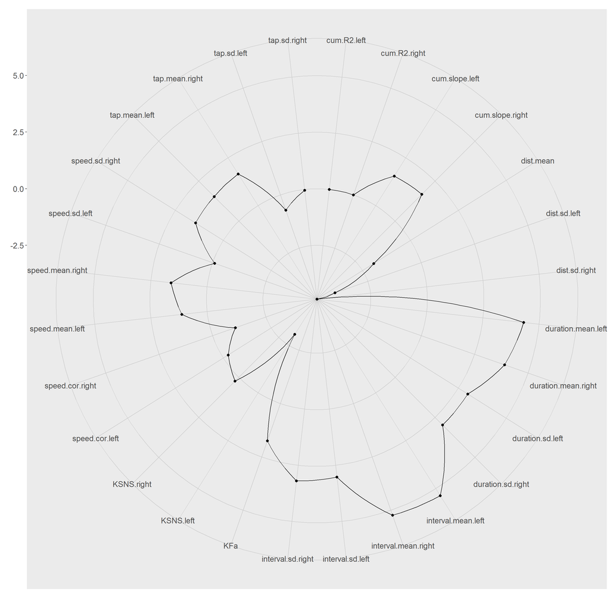